# 440 CS3 IR2

#### Exploring Numerical Continuous Variables

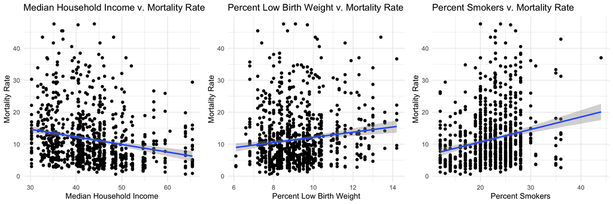

As shown in the scatterplots above, there is a positive relationship between mortality rate with percentage of smokers (correlation of 0.2182623) as well as percentage of births that had a low birth weight (correlation of 0.1377997). On the other hand, there is a negative relationship between the median household income and the mortality rate in that county (correlation of -0.2169295). These relationships suggest a possibility of incorporating these factors as appropriate predictors in our model.

```
## Generalized linear mixed model fit by maximum likelihood (Laplace
##   Approximation) [glmerMod]
##  Family: binomial  ( logit )
## Formula:
## mortality_rate ~ (1 | COUNTY) + (1 | race) + Median_Household_Income +
##     pctLowBirthWeight + pctSmokers
##    Data: mortality
## Weights: births
##
##      AIC      BIC   logLik deviance df.resid
##   3888.1   3917.4  -1938.0   3876.1      972
##
## Scaled residuals:
##     Min      1Q  Median      3Q     Max
## -2.3013 -0.6103  0.0460  0.7903  9.3941
##
## Random effects:
##  Groups Name        Variance Std.Dev.
##  COUNTY (Intercept) 0.01187  0.1090
##  race   (Intercept) 0.10676  0.3267
## Number of obs: 978, groups:  COUNTY, 100; race, 5
##
## Fixed effects:
##                          Estimate Std. Error z value Pr(>|z|)
## (Intercept)             -3.951155   0.412874  -9.570  < 2e-16 ***
## Median_Household_Income -0.017573   0.003987  -4.407 1.05e-05 ***
## pctLowBirthWeight       -0.033046   0.020175  -1.638  0.10143
## pctSmokers               0.018370   0.005606   3.277  0.00105 **
## ---
## Signif. codes:  0 '***' 0.001 '**' 0.01 '*' 0.05 '.' 0.1 ' ' 1
##
## Correlation of Fixed Effects:
##             (Intr) Md_H_I pctLBW
## Mdn_Hshld_I -0.829
## pctLwBrthWg -0.737  0.536
## pctSmokers  -0.612  0.553  0.187
```

```
## Generalized linear mixed model fit by maximum likelihood (Laplace
##   Approximation) [glmerMod]
##  Family: binomial  ( logit )
## Formula: mortality_rate ~ (1 | COUNTY) + race + Median_Household_Income +
##     pctLowBirthWeight + pctSmokers
##    Data: mortality
## Weights: births
##
##      AIC      BIC   logLik deviance df.resid
##   3871.0   3914.9  -1926.5   3853.0      969
##
## Scaled residuals:
##     Min      1Q  Median      3Q     Max
## -2.2984 -0.6082  0.0479  0.8026  9.2372
##
## Random effects:
##  Groups Name        Variance Std.Dev.
##  COUNTY (Intercept) 0.01129  0.1062
## Number of obs: 978, groups:  COUNTY, 100
##
## Fixed effects:
##                          Estimate Std. Error z value Pr(>|z|)
## (Intercept)             -4.401973   0.381597 -11.536  < 2e-16 ***
## raceAmerican Indian      0.710734   0.136104   5.222 1.77e-07 ***
## raceBlack                0.913599   0.035723  25.574  < 2e-16 ***
## raceHispanic             0.235819   0.053102   4.441 8.96e-06 ***
## raceOther Non-White      0.430897   0.097844   4.404 1.06e-05 ***
## Median_Household_Income -0.017454   0.003962  -4.406 1.05e-05 ***
## pctLowBirthWeight       -0.033690   0.020066  -1.679 0.093171 .
## pctSmokers               0.018374   0.005573   3.297 0.000977 ***
## ---
## Signif. codes:  0 '***' 0.001 '**' 0.01 '*' 0.05 '.' 0.1 ' ' 1
##
## Correlation of Fixed Effects:
##             (Intr) rcAmrI rcBlck rcHspn rcON-W Md_H_I pctLBW
## rcAmrcnIndn -0.020
## raceBlack    0.076  0.162
## raceHispanc  0.010  0.092  0.340
## rcOthrNn-Wh  0.032  0.038  0.201  0.137
## Mdn_Hshld_I -0.893  0.075 -0.048 -0.045 -0.056
## pctLwBrthWg -0.782 -0.051 -0.245 -0.064 -0.061  0.536
## pctSmokers  -0.666  0.002  0.072  0.050  0.035  0.556  0.191
## convergence code: 0
## Model failed to converge with max|grad| = 0.119203 (tol = 0.001, component 1)
## Model is nearly unidentifiable: very large eigenvalue
##  - Rescale variables?
```

```
## Generalized linear mixed model fit by maximum likelihood (Laplace
##   Approximation) [glmerMod]
##  Family: binomial  ( logit )
## Formula: mortality_rate ~ (1 | COUNTY) + (1 | race)
##    Data: mortality
## Weights: births
##
##      AIC      BIC   logLik deviance df.resid
##   3928.4   3943.1  -1961.2   3922.4      975
##
## Scaled residuals:
##     Min      1Q  Median      3Q     Max
## -2.3793 -0.5461  0.0438  0.7886  9.0339
##
## Random effects:
##  Groups Name        Variance Std.Dev.
##  COUNTY (Intercept) 0.05139  0.2267
##  race   (Intercept) 0.12096  0.3478
## Number of obs: 978, groups:  COUNTY, 100; race, 5
##
## Fixed effects:
##             Estimate Std. Error z value Pr(>|z|)
## (Intercept)  -4.5525     0.1626  -27.99   <2e-16 ***
## ---
## Signif. codes:  0 '***' 0.001 '**' 0.01 '*' 0.05 '.' 0.1 ' ' 1
```

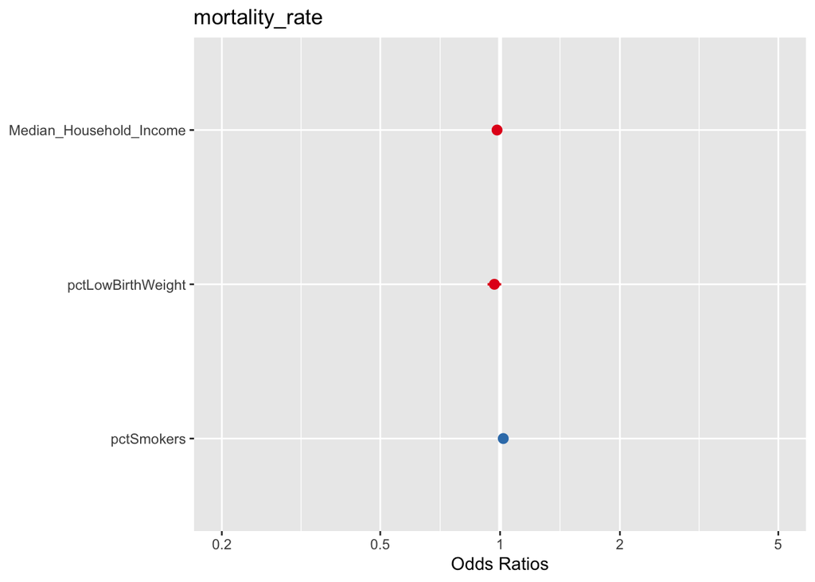